# Preprossessing data analysis for Iron and gut microbiome project data

2026-03-25

```r
# Let's see where chloroplasts are and also mitochondria

# How to access what is in a phyloseq table
view(tax_table(raw_physeq))
view(otu_table(raw_physeq))

# Make new physeq without chloroplasts
noChloros_physeq <-
  raw_physeq %>%
  subset_taxa(Order != "Chloroplast" | is.na(Order))

# How many taxa were chloroplasts?
num_chloro_ASVs <- ntaxa(raw_physeq) - ntaxa(noChloros_physeq)
num_chloro_ASVs
```

```
## [1] 0
```

```r
# remove mitochondria
noChlorosMitos_physeq <-
  noChloros_physeq %>%
  subset_taxa(Family != "Mitochondria" | is.na(Family))

# How many mitochondrial ASVs?
num_mito_ASVs <- ntaxa(noChloros_physeq) - ntaxa(noChlorosMitos_physeq)
num_mito_ASVs
```

```
## [1] 0
```

```r
# Let's take a quick look
noChlorosMitos_physeq
```

```
## phyloseq-class experiment-level object
## otu_table()   OTU Table:         [ 1591 taxa and 102 samples ]
## sample_data() Sample Data:       [ 102 samples by 3 sample variables ]
## tax_table()   Taxonomy Table:    [ 1591 taxa by 9 taxonomic ranks ]
```

```r
# How many total asvs were removed from chloros and mitos?
ntaxa(raw_physeq) - ntaxa(noChlorosMitos_physeq)
```

```
## [1] 0
```

```r
# proportion of asvs kept?
ntaxa(noChlorosMitos_physeq)/ntaxa(raw_physeq)
```

```
## [1] 1
```

### Interpretation 1:

In this project dataset, there are no chlorophyll and mitochondria ASV being detected. This is not superising, as they used a different primer set for V5-V6 which is less commonly applied for bacterial 16s sequencing. I think more generally/prevalently used primers might give higher detection rate of those contaminants, and the results seeing here is suggesting this dataset has good primer specificity with no host/dietary carryover.

### Interpretation 2 and 3:

This project dataset has no negative control and no mock community. It’s harder to assess the accuracy of the sequencing, this is certainly a limitation in their microbial sequencing study design.

```r
# Pull out Taxa Table
tax_table <-
  noChlorosMitos_physeq %>%
  tax_table() %>%
  data.frame()

# Grab ASV Sequences and Names
asv_names <- tax_table$ASV
asv_seqs <- tax_table$ASVseqs

# Create empty comparison matrix
asv_rev_comp <- matrix(nrow=length(asv_seqs), ncol = length(asv_seqs))

# Fix the names in the rows and columns
rownames(asv_rev_comp) <- asv_names
colnames(asv_rev_comp) <- asv_names

# Convert sequences to Biostrings
asv_dna <- DNAStringSet(asv_seqs)

# Inspect
head(asv_dna)
```

```
## DNAStringSet object of length 6:
##     width seq
## [1]   290 GTCCACGCCGTAAACGATGAGGACCAAGTGTTGG...AGCTCGTGTCGTGAGATGTTGGGTCAAGTCCCG
## [2]   298 GTCCATGCCGTAAACGATGAGTGCTAAGTGTTGG...AGCTCGTGTCGTGAGATGTTGGGTTAAGTCCCG
## [3]   290 GTCCTAGCCGTAAACGATGGACGCTAGGTGTGGG...AGCTCGTGTCGTGAGATGTTGGGTTAAGTCCCG
## [4]   298 GTCCACGCCGTAAACGGTGGATGCTGGATGTGGG...AGCTCGTGTCGTGAGATGTTGGGTTAAGTCCCG
## [5]   293 GTCCACACGGTAAACGATGAATACTCGCTGTTTG...AGCTCGTGCCGTGAGGTGTCGGCTTAAGTGCCA
## [6]   298 GTCCACGCCGTAAACGATGAATGCTAAGTGTTGG...AGCTCGTGTCGTGAGATGTTGGGTTAAGTCCCG
```

```r
# Construct reverse complement
asv_rev_dna <- reverseComplement(asv_dna)

# Now loop through every asv sequence to check
for(i in 1:length(asv_seqs)){ # For each asv sequence...
  match_vec <- asv_dna[i] == asv_rev_dna # Compare it to the reverse complement of every other sequence...
  asv_rev_comp[,i] <- match_vec # Write that logical vector as a new column
}

# Find how many TRUEs (matches) we have, divide by 2 because each pair occurs twice
cat("For", sum(asv_rev_comp) / 2,"ASVs, the reverse complement will need to be removed")
```

```
## For 0 ASVs, the reverse complement will need to be removed
```

### Interpretation 4:

This dataset do no have any reverse compliments to be removed.

```r
# The current data object
noChlorosMitos_physeq
```

```
## phyloseq-class experiment-level object
## otu_table()   OTU Table:         [ 1591 taxa and 102 samples ]
## sample_data() Sample Data:       [ 102 samples by 3 sample variables ]
## tax_table()   Taxonomy Table:    [ 1591 taxa by 9 taxonomic ranks ]
```

```r
# Make a metadata_df for joining
metadata_df <-
  noChlorosMitos_physeq %>%
  sample_data() %>%
  data.frame()

library(tibble)

metadata_df <- metadata_df %>%
  rownames_to_column(var = "names")

# What is the library size/sequencing depth for each sample?
seqSums_df <-
  noChlorosMitos_physeq %>%
  otu_table() %>%
  # Sum each sample column
  colSums() %>%
  data.frame() %>%
  rownames_to_column(var = "names") %>%
  left_join(., metadata_df, by = "names")

# Rename second column
colnames(seqSums_df)[2] <- "TotalSeqs"

# check
dim(seqSums_df)
```

```
## [1] 102   5
```

```r
head(seqSums_df)
```

```
##         names TotalSeqs  ID Group Iron.intake
## 1 SRR29920099     42560 100   CRC         500
## 2 SRR29920100     40601  99   CRC         500
## 3 SRR29920101     35469  98   CRC         500
## 4 SRR29920102     44925  97   CRC         500
## 5 SRR29920103     43217  96   CRC         500
## 6 SRR29920104     36595  95   CRC         500
```

```r
# Show the depth of samples
seqSums_df %>%
  dplyr::select(names, TotalSeqs) %>%
  arrange(TotalSeqs) %>%
  head()
```

```
##         names TotalSeqs
## 1 SRR29920166     21454
## 2 SRR29920174     21639
## 3 SRR29920149     22060
## 4 SRR29920164     23345
## 5 SRR29920181     24687
## 6 SRR29920167     25180
```

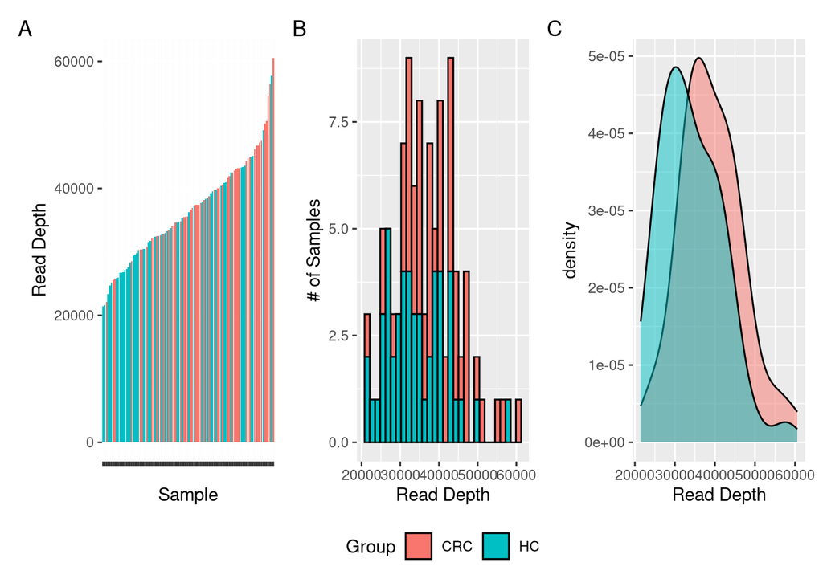

```r
numSeq_bar_plot <-
  seqSums_df %>%
  ggplot(aes(x = reorder(names, TotalSeqs), y = TotalSeqs, fill = Group)) +
  geom_col() +
  theme(axis.text.x = element_blank()) +
  labs(y = "Read Depth", x = "Sample") +
  theme(legend.position = "none")

numSeq_hist_plot <-
  seqSums_df %>%
  ggplot(aes(x = TotalSeqs, fill = Group)) +
  geom_histogram(color = "black") +
  labs(y = "# of Samples", x = "Read Depth") +
  theme(legend.position = "bottom")

numSeq_density_plot <-
  seqSums_df %>%
  ggplot(aes(x = TotalSeqs, fill = Group)) +
  geom_density(alpha = 0.5) +
  labs(x = "Read Depth") +
  theme(legend.position = "none")

numSeq_bar_plot + numSeq_hist_plot + numSeq_density_plot +
  plot_annotation(tag_levels = "A")
```

```r
# What's the min seq depth?
min(sample_sums(noChlorosMitos_physeq))
```

```
## [1] 21454
```

```r
# Final check of the sequencing depth for now
# Here, we could remove more samples if we needed to
seqSums_df %>%
  dplyr::select(names, TotalSeqs) %>%
  arrange(TotalSeqs)
```

```
##           names TotalSeqs
## 1   SRR29920166     21454
## 2   SRR29920174     21639
## 3   SRR29920149     22060
## 4   SRR29920164     23345
## 5   SRR29920181     24687
## 6   SRR29920167     25180
## 7   SRR29920150     25550
## 8   SRR29920152     25667
## 9   SRR29920178     25873
## 10  SRR29920153     25919
## 11  SRR29920177     26683
## 12  SRR29920192     26764
## 13  SRR29920191     26809
## 14  SRR29920142     27218
```

[output cut: 88 more lines]

```r
preprocessed_physeq <- noChlorosMitos_physeq
```

### Interpretation 5:

The minimum reads is 21454 which shall be good for 16s. The greatest read is in 60K which is ~3-fold greater than the minimal so rarefaction is recommended for downstream comparison. While the read depths for all samples are generally good, the sequencing depth slightly differed between treatment groups with the CRC groups getting more reads than the HC (healthy controls), which shall be considered when comparing diversity. But rarefactino will help with this when comparing differential abundances. The overall sequencing depth is good in general.

```r
# Let's add a metadata column to the file for this dataset
metadata_df <-
  preprocessed_physeq %>%
  sample_data() %>%
  data.frame() %>%
  rownames_to_column(var = "SampleID") %>%
  mutate(
    Iron_dose_mg = as.numeric(Iron.intake),
    Group = factor(Group,
                   levels = c("HC", "CRC"),
                   ordered = TRUE),
    Iron.intake = factor(Iron.intake,
                         levels = c(50, 500),
                         labels = c("Low iron", "High iron"),
                         ordered = TRUE),
    Group_Iron = factor(
      paste(Group, Iron.intake, sep = "_"),
      levels = c("HC_Low iron", "HC_High iron",
                 "CRC_Low iron", "CRC_High iron"),
      ordered = TRUE
    ),
    ID = factor(ID, ordered = TRUE)
  )

### Let's add the sequencing count data, so that doesn't get lost!
# What are the sample size distributions?# Per-sample sequencing depth
num_seqs_df <-
  preprocessed_physeq %>%
  sample_sums() %>%
  data.frame() %>%
  rownames_to_column(var = "SampleID")

colnames(num_seqs_df)[2] <- "Sequencing_Depth"

# Merge sequencing depth into metadata
metadata_df2 <-
  metadata_df %>%
  left_join(num_seqs_df, by = "SampleID")

## Check they match
stopifnot(metadata_df$SampleID == metadata_df2$SampleID)

# Rename the rows
rownames(metadata_df2) <- metadata_df2$SampleID

# Reassign to the phyloseq object, rewriting the old metadata
sample_datapreprocessed_physeq <- metadata_df2

# Double check
colnames(data.frame(sample_data(preprocessed_physeq)))
```

```
## [1] "ID"          "Group"       "Iron.intake"
```

```r
# Intuition check
head(num_seqs_df)
```

```
##      SampleID Sequencing_Depth
## 1 SRR29920099            42560
## 2 SRR29920100            40601
## 3 SRR29920101            35469
## 4 SRR29920102            44925
## 5 SRR29920103            43217
## 6 SRR29920104            36595
```

```r
# Please be sure to use the correct path to the appropriate directory in your file system
save(preprocessed_physeq, file = "/local/workdir/yz3272/BIOMI6300_IronMicrobiotaProject/03_Pre-processing/preprocessed_phyloseq.RData")
```

```r
# Take the time now that we are at the end of the script
end_time <- Sys.time()
end_time
```

```
## [1] "2026-04-15 15:34:14 EDT"
```

```r
# Echo the elapsed time
elapsed_time <- round((end_time - start_time), 3)
elapsed_time
```

```
## Time difference of 13.294 secs
```